# Statistisk inferensteori Frekventistisk likelihoodteori (H & B, Kapitel 4)

## Likelihoodfunktionens statistiska egenskaper

## Fishers regularitetsvillkor

**Definition:** (H & B, def. 4.1). En statistisk modell \(\mathcal{P}\) säges uppfylla Fishers regularitetsvillkor om:

- \(\Theta\) är ett öppet intervall,
- stödet hos \(x\mapsto p(x|\theta)\) beror inte på \(\theta\),
- \(\theta_1\neq \theta_2\Rightarrow\) \(p(\cdot|\theta_1)\neq p(\cdot|\theta_2)\) (identifierbarhet)
- \(L(\theta)\) är två gånger kontinuerligt differentierbar för alla \(x\in\mathcal{T}\),
- \(\frac{d^2}{d\theta^2}\int p(x|\theta)\,dx=\int \frac{d^2}{d\theta^2}p(x|\theta)\,dx\) för alla \(\theta\in\Theta\).

## Förväntad Fisherinformation

**Definition:** (H & B, def. 4.2). De förväntade Fisherinformationen hos en modell \(\mathcal{P}\) är \[ J(\theta)=E_\theta(I(\theta;X)), \theta\in\Theta, \] där \(I(\theta;x)\) är Fisherinformationen givet ett observerat stickprov \(x\).

## Egenskaper hos scorefunktion

**Sats:** (H & B, result 4.1). Under Fishers regularitetsvillkor gäller att \[ E_\theta(S(\theta;X))=0, \theta\in\Theta, \] och \[ Var_\theta(S(\theta;X))=J(\theta), \theta\in\Theta, \] där \(S(\theta;x)\) är scorefunktionen givet ett observerat stickprov \(x\).

## Scorestatistikan

**Sats:** Låt \(X_{1:n}=(X_1,\ldots,X_n)\sim P_\theta^n\) vara en sekvens oberoende likafördelade stokastiska variabler. Då gäller under Fishers regularitetsvillkor att \[ \frac{S(\theta; X_{1:n})^2}{J(\theta)}\rightarrow Z\sim \chi^2(1) \] och \[ \frac{S(\theta; X_{1:n})^2}{I(\theta; X_{1:n})}\rightarrow Z\sim \chi^2(1) \] med konvergens i fördelning då \(n\rightarrow\infty\).

## ML-skattarens asymptotik

## Harald Cramér (1893-1985)

[figure not shown]

## Cramér-Raos olikhet (informationsolikheten)

**Sats:** (H & B, result 4.8) Låt \(T=h(X)\), \(X\sim P_\theta\), vara en väntevärdesriktig skatttare av \(\theta\). Då gäller under Fishers regularitetsvillkor att \[ Var_\theta(T)\geq \frac{1}{J(\theta)}. \]

**Definition:** En sekvens skattare, \(T_n\), säges vara effektiv om \[ \sqrt{J_n(\theta)}(T_n-\theta)\rightarrow Z\sim N(0,1) \] i fördelning då \(n\rightarrow\infty\).

## ML-skattaren är konsistent

**Sats:** (H & B, result 4.9) Låt \(X_1, \ldots, X_n\) vara \(n\) oberoende likafördelade observationer från \(P_\theta\). Då finns en konsistent sekvens av ML-skattare.

## ML-skattarens asymptotiska fördelning

**Sats:** (H & B, result 4.10) Låt \(\hat{\theta}_n\) vara en konsistent sekvens av ML-skattare av \(\theta\) baserad på \(n\) oberoende likafördelade observationer från \(P_\theta\). Då gäller under Fishers regularitetsvillkor att \[ \sqrt{J_n(\theta)}(\hat{\theta}_n-\theta)\rightarrow Z\sim N(0,1), \] d.v.s. ML-skattaren är effektiv.

## Likelihood-kvot statistikan

**Definition:** Likelihood-kvot statistikan är \[ T_L(\theta)=-2\tilde{l}(\theta)=-2(l(\theta)-l(\hat{\theta})) \] med en asymptotisk \(\chi^2(1)\)-fördelning då \(X_{1:n}\sim P_\theta^n\).

## Livslängder: Wald och Likelihood-kvot statistikan

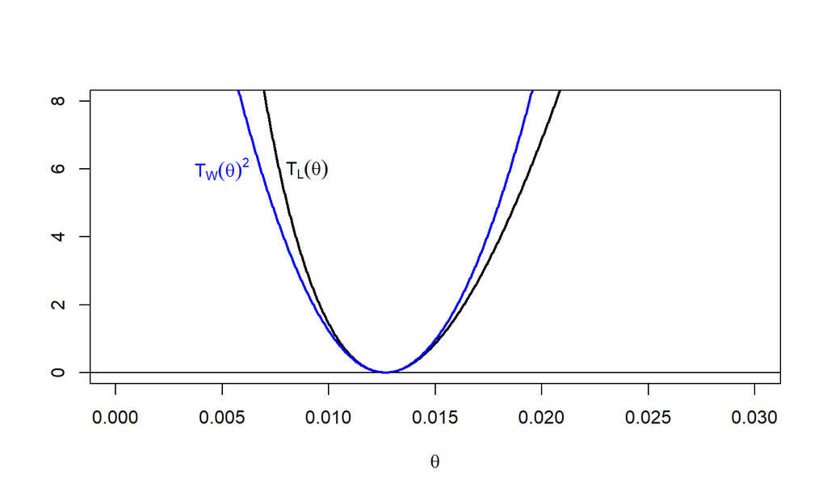

## Livslängder: Konfidensintervall med Score-statistikan

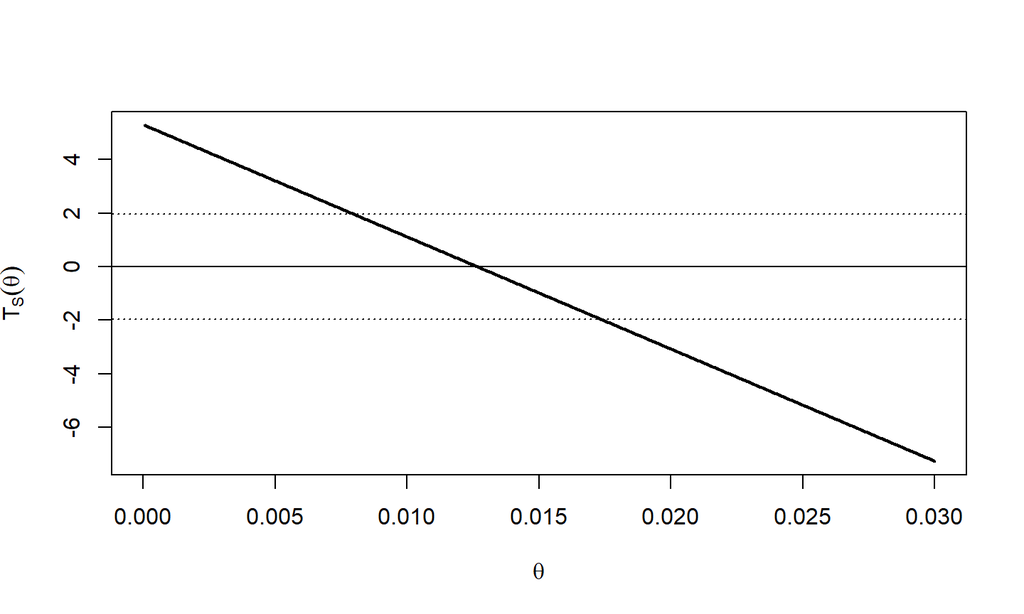

## Livslängder: Konfidensintervall med Likelihood-kvot statistikan

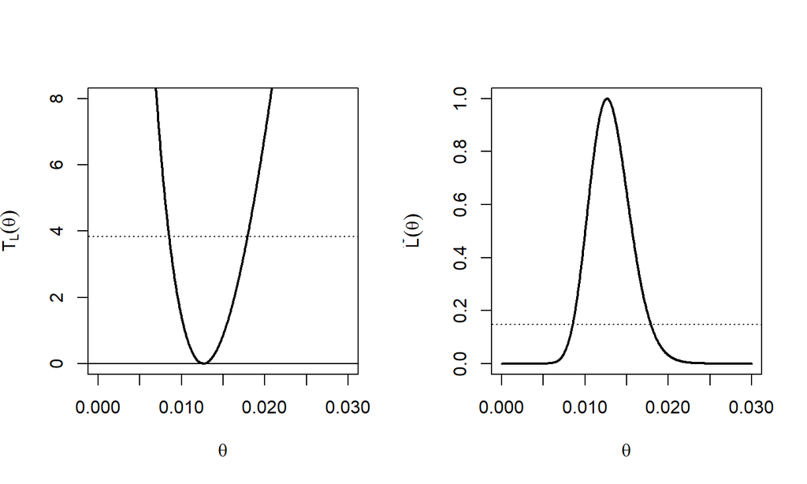

## Livslängder: Konfidensintervall med Likelihood-kvot statistikan

```r
f <- function(theta, data){
  theta.hat <- 1 / mean(data)
  f.out <- -2 * (l.exp(theta, ac) - l.exp(theta.hat, ac)) - qchisq(0.95, df = 1)
  return(f.out)
}
uniroot(f, interval = c(0, theta.hat), data = ac)$root
```

```
## [1] 0.008523913
```

```r
uniroot(f, interval = c(theta.hat, 0.02), data = ac)$root
```

```
## [1] 0.01793043
```

## Tester

```r
theta0 <- 0.01
TS2 <- S.exp(theta0, ac)^2 / I.exp(theta0, ac)
1-pchisq(TS2, 1)
```

```
## [1] 0.2681055
```

```r
TW2 <- (theta.hat - theta0)^2 * I.exp(theta0, ac)
1-pchisq(TW2, 1)
```

```
## [1] 0.1613483
```

```r
TL <- -2 * (l.exp(theta0, ac) - l.exp(theta.hat, ac))
1-pchisq(TL, 1)
```

```
## [1] 0.2317904
```

## Jämförelse Wald, Score och Likelihood-kvot som test-statistikor

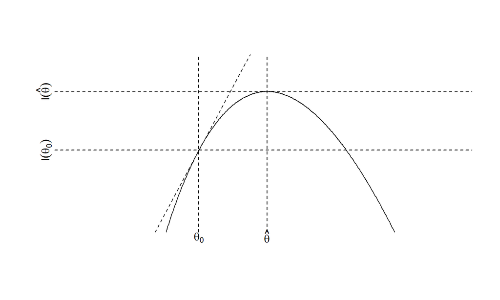

## Utan asymptotik…

```r
N <- 10000
TS2.mc <- numeric(N); TW2.mc <- numeric(N); TL.mc <- numeric(N)
for (i in 1:N){
    x <- rexp(28, rate = theta0)
    theta.hat.mc <- 1 / mean(x)
    TS2.mc[i] <- S.exp(theta0, x)^2 / I.exp(theta0, x)
    TW2.mc[i] <- (theta.hat.mc - theta0)^2 * I.exp(theta0, x)
    TL.mc[i] <- -2 * (l.exp(theta0, x) - l.exp(theta.hat.mc, x))
}
c(mean(TS2.mc > TS2), mean(TW2.mc > TW2), mean(TL.mc > TL))
```

```
## [1] 0.2615 0.1624 0.2300
```